# Sds2 Project

Giacomo Maretto

09 gennaio 2019

# Airlines Fatalities

## Introduction

In this project we are analyzing data collected from 1976 to 2001 about airline fatal accidents by the International Civil Aviation Organization in Montreal , Canada (www.icao.int).

Our goal is to get a good prediction about future fatalitis through a bayesian approach.

Our data is structured with four columns, year, fatal, miles, rate.

“Passenger miles” are in units of $10^{11}$ and the “accident rate” is the number of fatal accidents per $10^{11}$ passenger miles.

| year | fatal | miles | rate |
| --- | --- | --- | --- |
| 1976 | 24 | 3.863 | 6.213 |
| 1977 | 25 | 4.3 | 5.814 |
| 1978 | 31 | 5.027 | 6.167 |
| 1979 | 31 | 5.481 | 5.656 |
| 1980 | 22 | 5.814 | 3.784 |
| 1981 | 21 | 6.033 | 3.481 |
| 1982 | 26 | 5.877 | 4.424 |
| 1983 | 20 | 6.223 | 3.214 |
| 1984 | 16 | 7.433 | 2.152 |
| 1985 | 22 | 7.107 | 3.096 |
| 1986 | 22 | 9.1 | 2.418 |
| 1987 | 25 | 10 | 2.5 |
| 1988 | 29 | 10.6 | 2.736 |
| 1989 | 29 | 10.99 | 2.639 |
| 1990 | 27 | 10.88 | 2.482 |
| 1991 | 29 | 10.63 | 2.727 |
| 1992 | 28 | 11.96 | 2.342 |
| 1993 | 33 | 12.34 | 2.674 |
| 1994 | 27 | 13.01 | 2.075 |
| 1995 | 25 | 14.22 | 1.758 |
| 1996 | 24 | 16.37 | 1.466 |
| 1997 | 26 | 15.48 | 1.679 |
| 1998 | 20 | 18.08 | 1.106 |
| 1999 | 21 | 16.63 | 1.263 |
| 2000 | 18 | 18.88 | 0.954 |
| 2001 | 13 | 19.23 | 0.676 |

### Following three descriptive time series plot respectively about the number of fatal accidents, the miles flown and the accident rate per each year.

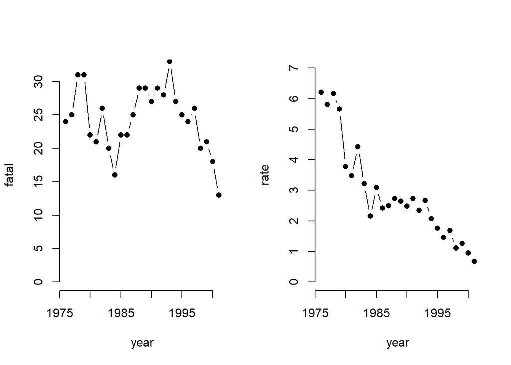

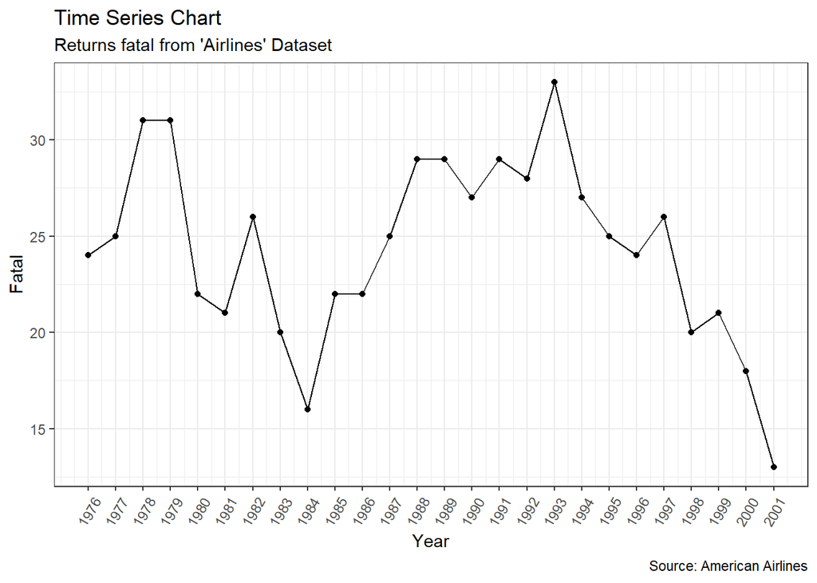

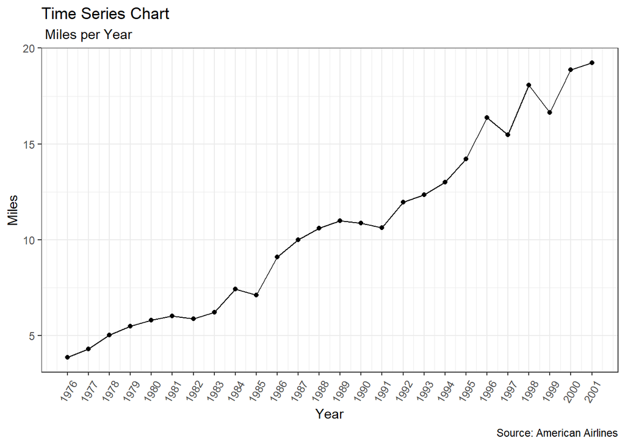

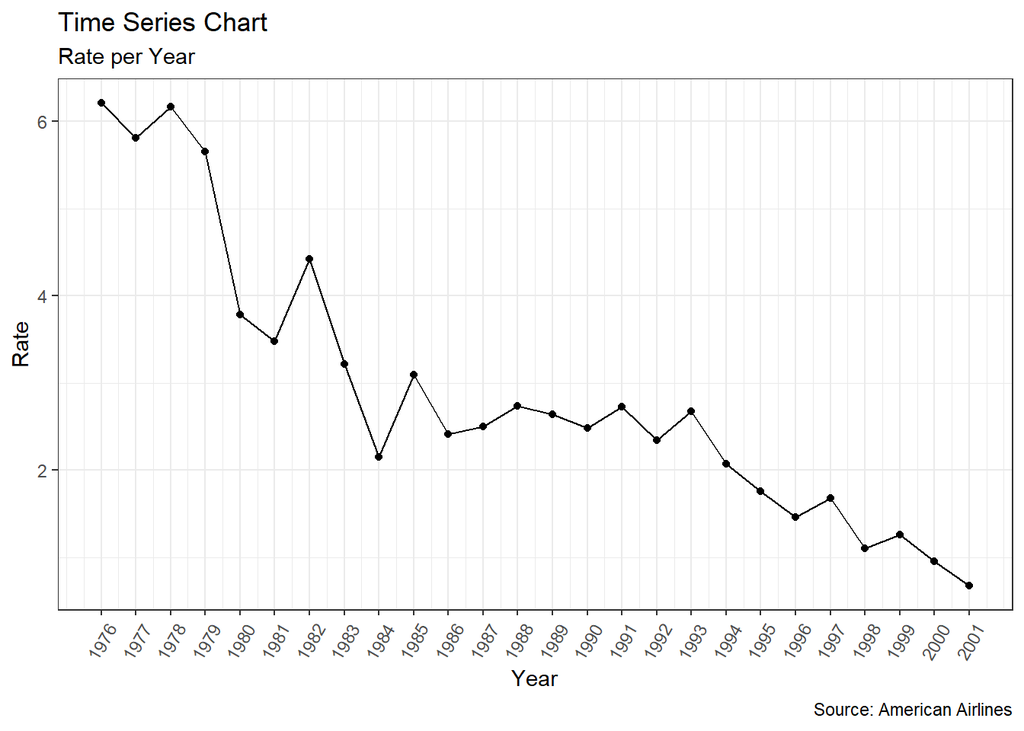

started with the simplest model i could immagine, that simply all the years look the same. This means that the number of fatal accidents in each year are independend with a $Poisson(\theta)$ distribution. I set a non informative gamma prior distribution for $\theta$, that has $(\alpha, \beta) = (0.01,0.01)$

The model for the data is:

where $\theta$ is the expected number of fatal accidents in an year. If the prior distribution for $\theta$ is $(\Gamma(\alpha,\beta))$ then the posterior distrubution is $\Gamma(\alpha+n\bar y,\beta+n)$, where in this case $n=26$ and $n\bar y= \sum^{26}_{i=1}y_i=634$
$$y_i|\theta \sim Poisson(\theta)$$
with:

```
        $\theta \sim Gamma(0.01,0.01)$
```

## Posterior distribution

The posterior distribution for $\theta$ is $\theta|y \sim \Gamma(634,26)$ and the conditional distribution of $\tilde{y}$ (the number of fatal accidents in 2002) is $Poisson(\theta)$.

So to simulate values of $\tilde{y}$ all we need to do is first generate a realized value form the posterior distribution of $\theta$ as the mean. Iterating this process will generate values of $\tilde{y}$ from the posterior predictive distribution. What we are doing here is integrating numerically, using simulation, over the posterior distrobution in $\theta$. We can simulate this easily in R.

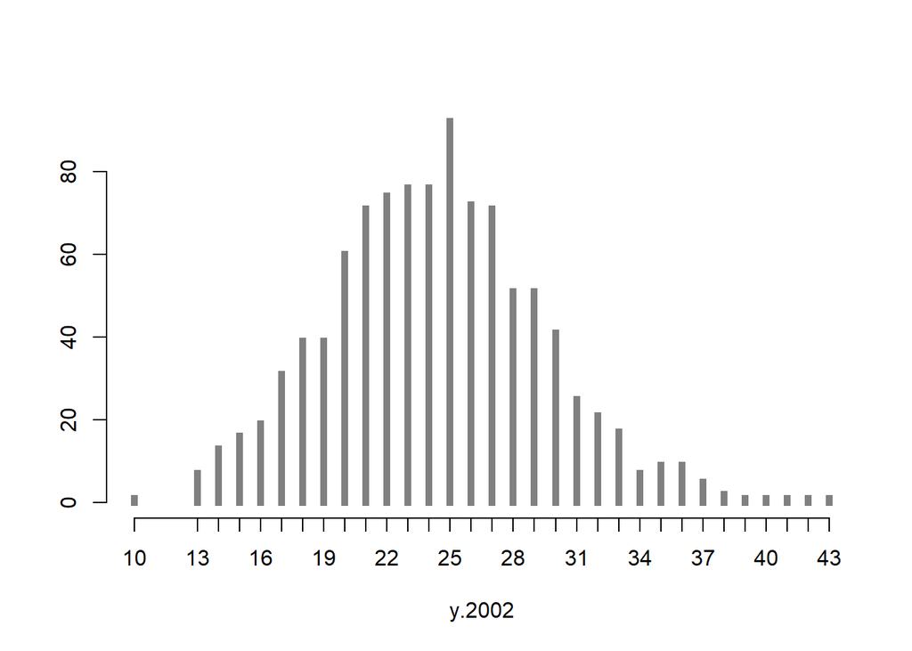

```r
theta <- rgamma(1000, 634, 26 )
y.2002 <- rpois(1000,theta)
#hist( y.2002 )
plot( table(y.2002), type="h", lwd=5, lend=2, col=gray(0.5), bty="n", ylab="" )
```

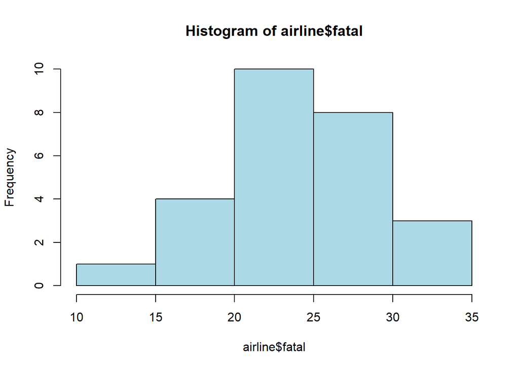

```r
hist(airline$fatal,col = "lightblue")
```

We can specify the model in R using the package rJags.

## First model

```r
cat( "model {
  for( i in 1:I ) {
    fatal[i] ~ dpois(mu)
    }
    mu ~ dgamma(0.01,0.01)
  }", file="a1.jag" )

a1.par <- c("mu","fatal[27]")

a1.ini <- list(list( mu=22 ),
              list( mu=23 ),
              list( mu=24 ) )

a1.dat <- list( fatal = c(airline$fatal,NA), I=27 )

# Model compilation and burn-in
a1.mod <- jags.model( file = "a1.jag",
                    data = a1.dat,
                    inits = a1.ini,
                    n.chains = 3,
                    n.adapt = 1000 )
# Sampling from the posterior
a1.res <- coda.samples( a1.mod,
                      var = a1.par,
                      n.iter = 10000,
                      thin = 10 )
summary( a1.res )
```

```
##
## Iterations = 10:10000
## Thinning interval = 10
## Number of chains = 3
## Sample size per chain = 1000
##
## 1. Empirical mean and standard deviation for each variable,
##    plus standard error of the mean:
##
##            Mean     SD Naive SE Time-series SE
## fatal[27] 24.40 5.0218  0.09169        0.08754
## mu        24.39 0.9818  0.01792        0.01663
##
## 2. Quantiles for each variable:
##
##           2.5%   25%   50%   75% 97.5%
## fatal[27] 15.0 21.00 24.00 28.00 35.00
## mu        22.5 23.74 24.37 25.02 26.31
```

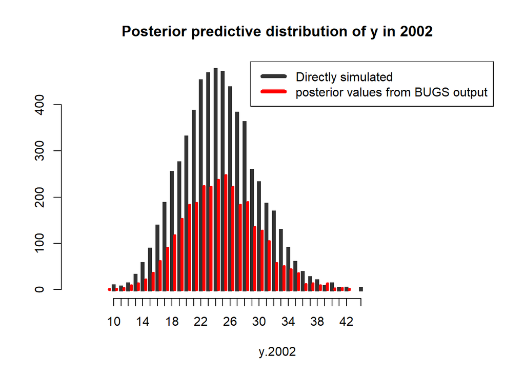

```r
theta <- rgamma(6000, 634, 26 )
y.2002 <- rpois(6000,theta)
plot( main = 'Posterior predictive distribution of y in 2002',table(y.2002), type="h", lwd=5, lend=2, col=gray(0.2), bty="n", ylab="", xlim=c(5,60) )
tpr <- table( as.matrix( a1.res[,"fatal[27]"] ) )
points( as.numeric(names(tpr))+0.4, tpr, type="h", col="red", lwd=4 )
legend("topright", c('Directly simulated','posterior values from BUGS output'),col=c(gray(0.2),'red'),lwd = 5)
```

## Diagnostics for model 1

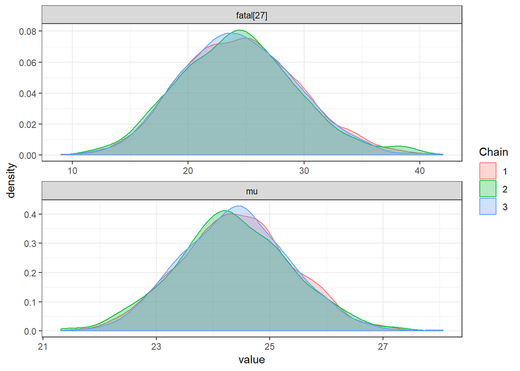

```r
result = ggs(a1.res)
ggs_density(result)
```

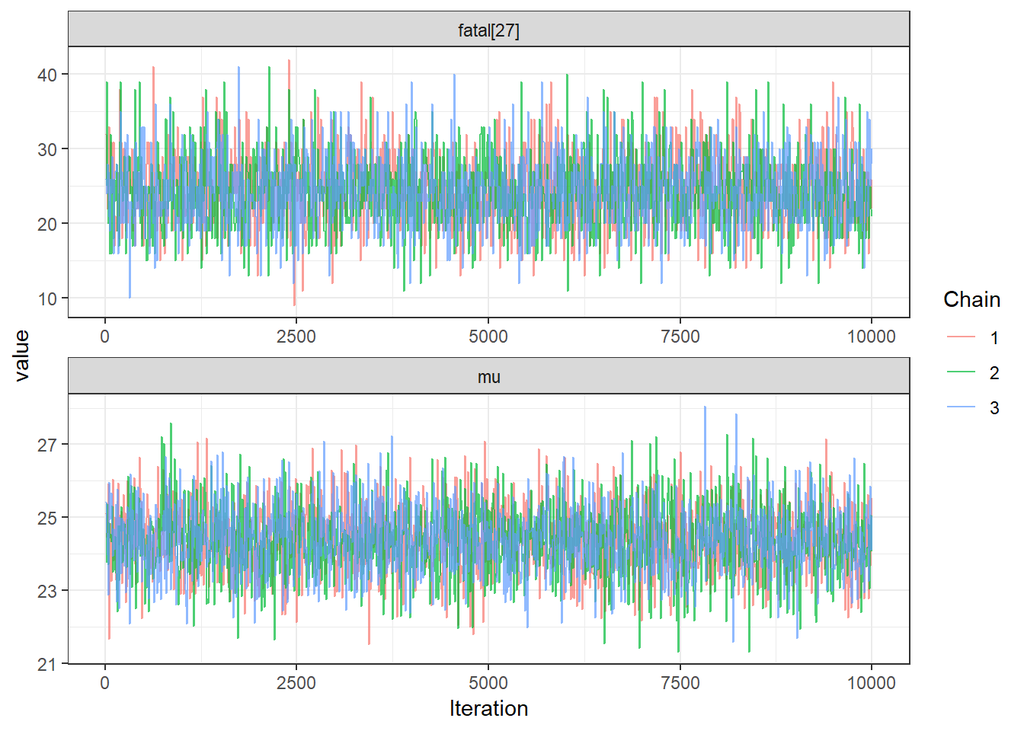

```r
ggs_traceplot(result)
```

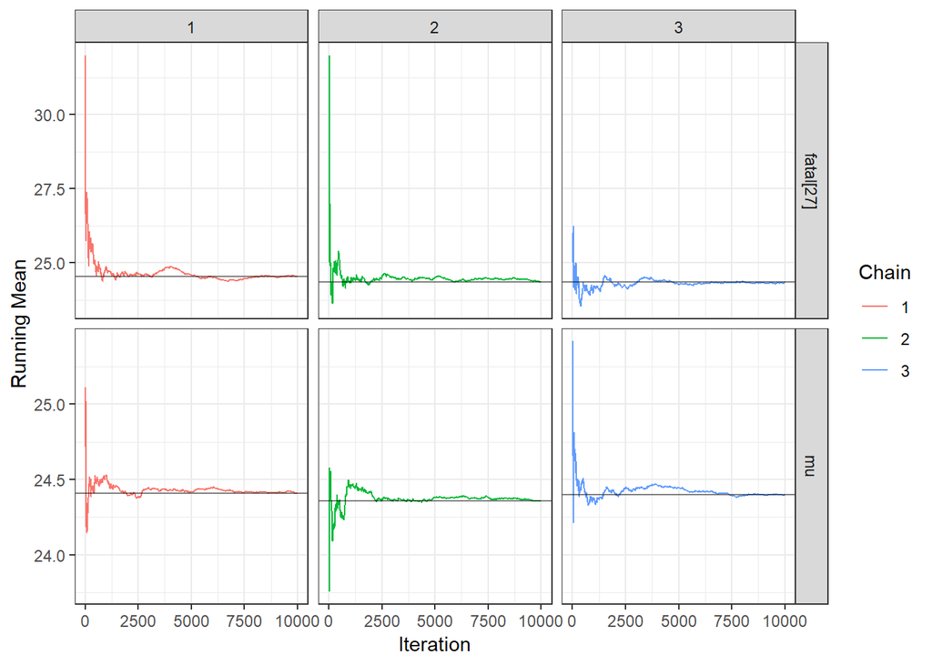

```r
ggs_running(result)
```

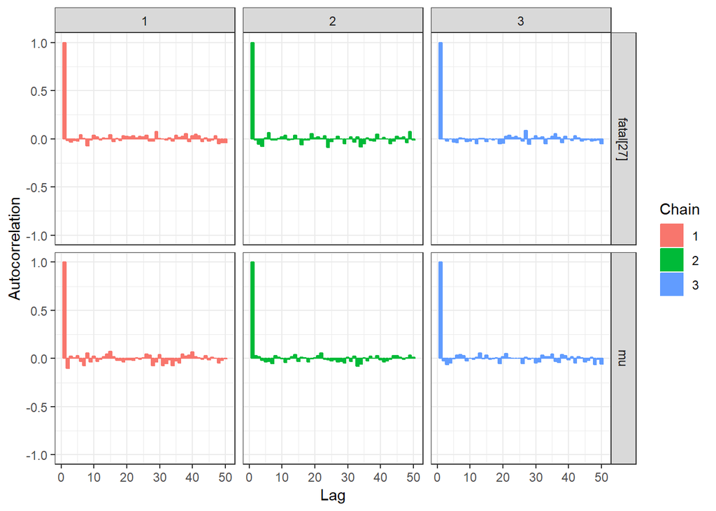

```r
ggs_autocorrelation(result)
```

## Model 2

A more natural model is the multiplicative one

$$log(E(y(t)|t,m(t))) = \alpha + \beta t + log(m(t))$$

with :

$$y_i \sim Pois(\mu)$$
and
$$\mu = exp(\alpha + \beta * year ) * miles$$

with uninformative ppriors:

$\alpha \sim Norm(0,0.000001)$ $\beta \sim Norm(0,0.000001)$

```r
summary(glm2 <- glm( fatal ~ I(year-1985) + offset(log(miles)),family=poisson,data=airline))
```

```
##
## Call:
## glm(formula = fatal ~ I(year - 1985) + offset(log(miles)), family = poisson,
##     data = airline)
##
## Deviance Residuals:
##     Min       1Q   Median       3Q      Max
## -2.0782  -0.7953   0.1626   0.7190   1.9369
##
## Coefficients:
##                 Estimate Std. Error z value Pr(>|z|)
## (Intercept)     1.176111   0.043200   27.23   <2e-16 ***
## I(year - 1985) -0.068742   0.005394  -12.74   <2e-16 ***
## ---
## Signif. codes:  0 '***' 0.001 '**' 0.01 '*' 0.05 '.' 0.1 ' ' 1
##
## (Dispersion parameter for poisson family taken to be 1)
##
##     Null deviance: 182.628  on 25  degrees of freedom
## Residual deviance:  22.545  on 24  degrees of freedom
## AIC: 157.02
##
## Number of Fisher Scoring iterations: 4
```

which shows that rates decrease about 7% per year.

We can now fit a model using JAGS

```r
cat( "model
 {
 for( i in 1:I )
 {
 mu[i] <- exp( alpha + beta*(i-10) ) * miles[i]
 fatal[i] ~ dpois( mu[i] )
 }
 alpha ~ dnorm(0,0.000001)
 beta ~ dnorm(0,0.000001)
 }",
 file="a2.jag" )
 a2.ini <- list( list( alpha=1.0, beta=-0.05 ),
 list( alpha=1.5, beta=-0.06 ),
 list( alpha=0.5, beta=-0.04 ) )
 a2.dat <- list( fatal=c(airline$fatal,NA),
 miles=c(airline$miles,20), I=27 )
 a2.par <- c("alpha","beta","fatal[27]")
 # Model compilation and burn-in
 a2.mod <- jags.model( file = "a2.jag",
 data = a2.dat,
 inits = a2.ini,
 n.chains = 3,
 n.adapt = 1000 )
 # Sampling from the posterior
 a2.res <- coda.samples( a2.mod,
 var = a2.par,
 n.iter = 10000,
 thin = 10 )
 summary( a2.res )
```

```
##
## Iterations = 1010:11000
## Thinning interval = 10
## Number of chains = 3
## Sample size per chain = 1000
##
## 1. Empirical mean and standard deviation for each variable,
##    plus standard error of the mean:
##
##               Mean      SD  Naive SE Time-series SE
## alpha      1.17388 0.04285 7.822e-04      0.0007819
## beta      -0.06877 0.00547 9.988e-05      0.0001048
## fatal[27] 20.26667 4.75862 8.688e-02      0.0851536
##
## 2. Quantiles for each variable:
##
##               2.5%      25%      50%      75%    97.5%
## alpha      1.08992  1.14619  1.17526  1.20226  1.25801
## beta      -0.07968 -0.07246 -0.06863 -0.06502 -0.05791
## fatal[27] 12.00000 17.00000 20.00000 23.00000 30.00000
```

```r
library( Epi )
ci.lin( glm2)
```

```
##                   Estimate      StdErr         z             P        2.5%
## (Intercept)     1.17611148 0.043199710  27.22499 3.287670e-163  1.09144161
## I(year - 1985) -0.06874189 0.005393721 -12.74480  3.332545e-37 -0.07931339
##                      97.5%
## (Intercept)     1.26078136
## I(year - 1985) -0.05817039
```

we can see that beta and year are virtually identical according to the CI seen here and the 95% posterior interval from the bugs simulation

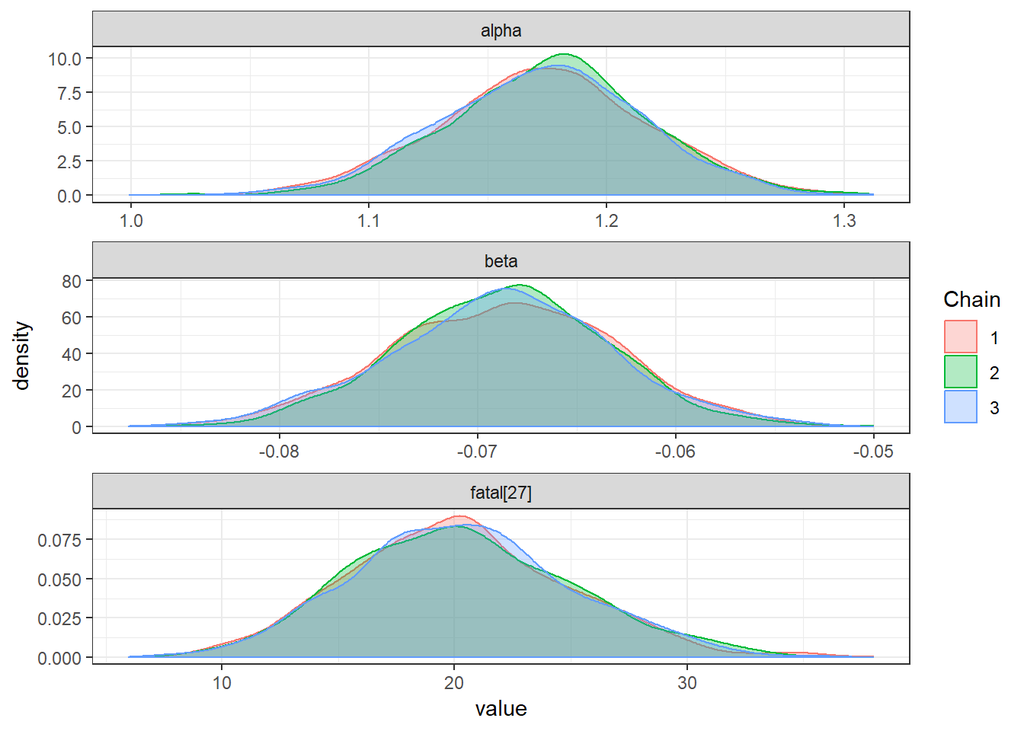

```r
result2 = ggs(a2.res)
ggs_density(result2)
```

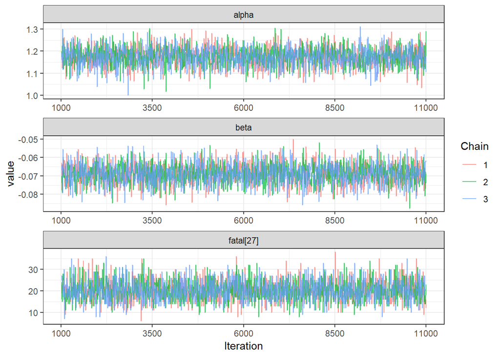

```r
ggs_traceplot(result2)
```

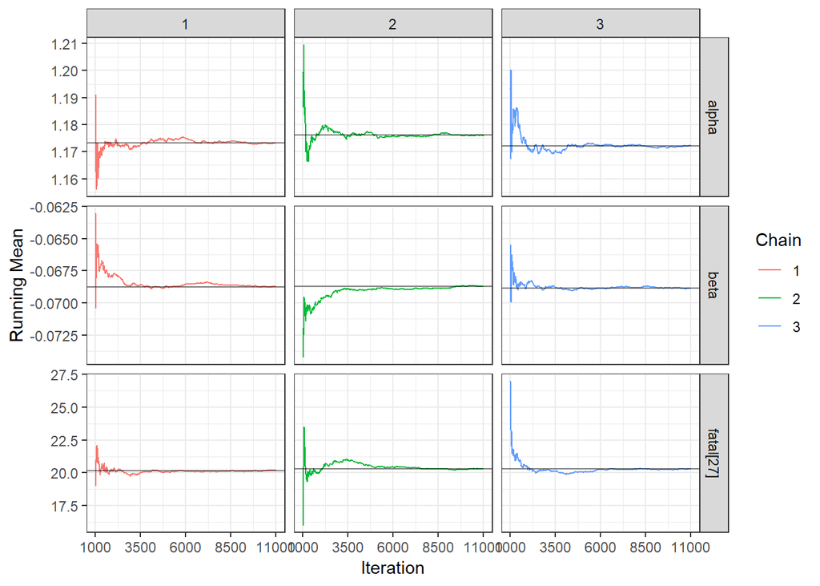

```r
ggs_running(result2)
```

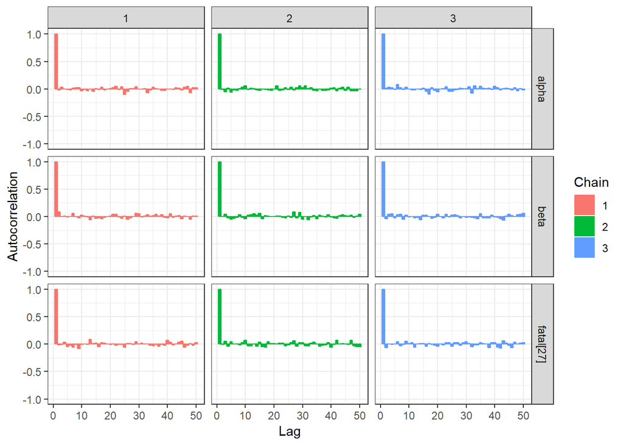

```r
ggs_autocorrelation(result2)
```

# Model 3

```r
library(rjags)
 cat( "model
 {
 for( i in 1:I )
 {
 fatal[i] ~ dpois( mu[i] )
 log(mu[i]) <- alpha + beta*miles[i]+ beta2 * miles[i]*rate[i]
 }
 alpha ~ dnorm(0,0.0001)
 beta ~ dnorm(0.0001,0.00001)
 beta2 ~ dnorm(0.0001,0.00001)
 }",

 file="a3.jag" )

 a3.ini= list(
    list(alpha = 0.01, beta = 0.6, beta2=0.1),
    list(alpha = 0.2, beta = 0.2, beta2=0.2),
    list(alpha = 0.7, beta = 0.7, beta2=0.3))
 a3.dat <- list( rate= c(airline$rate,0.7080,0.3,0.4),fatal=c(airline$fatal,NA,NA,NA), miles=c(airline$miles,19.775,23.300,20.3), I=29 )
 a3.par <- c("alpha","beta","beta2","fatal[27]","fatal[28]","fatal[29]")

 # Model compilation and burn-in
 a3.mod <- jags.model(file = "a3.jag",data = a3.dat,inits = a3.ini,n.chains = 3,n.adapt = 1000)
 update(a3.mod,1000)
 # Sampling from the posterior
 a33.res <- coda.samples( a3.mod,var = a3.par,n.iter = 10000,thin = 50 )
 summary( a33.res )
```

```
##
## Iterations = 2050:12000
## Thinning interval = 50
## Number of chains = 3
## Sample size per chain = 200
##
## 1. Empirical mean and standard deviation for each variable,
##    plus standard error of the mean:
##
##                 Mean       SD  Naive SE Time-series SE
## alpha      2.1306661 0.268979 0.0109810      0.0155807
## beta      -0.0007854 0.009227 0.0003767      0.0004467
## beta2      0.0430557 0.009119 0.0003723      0.0005116
## fatal[27] 15.2950000 4.333506 0.1769146      0.1771026
## fatal[28] 11.3266667 4.076066 0.1664047      0.1664306
## fatal[29] 11.9000000 3.980336 0.1624965      0.1678750
##
## 2. Quantiles for each variable:
##
##               2.5%       25%        50%       75%    97.5%
## alpha      1.57190  1.946066  2.1362732  2.313208  2.61509
## beta      -0.01939 -0.007088 -0.0007111  0.005587  0.01676
## beta2      0.02546  0.036387  0.0427766  0.049206  0.06303
## fatal[27]  8.00000 12.000000 15.0000000 18.000000 25.00000
## fatal[28]  4.00000  9.000000 11.0000000 14.000000 21.00000
## fatal[29]  5.00000  9.000000 12.0000000 14.000000 21.00000
```

```r
 #predictions
```

## fernando

```r
library(rjags)
 cat( "model
 {
 for( i in 1:I )
 {
 fatal[i] ~ dpois( mu[i] )
 log(mu[i]) <- alpha + beta2 * miles[i]*rate[i]
 }
 alpha ~ dnorm(0,0.0001)

 beta2 ~ dnorm(0.0001,0.00001)
 }",

 file="a3.jag" )

 a3.ini= list(
    list(alpha = 0.01, beta2=0.1),
    list(alpha = 0.2, beta2=0.2),
    list(alpha = 0.7,  beta2=0.3))
 a3.dat <- list( rate= c(airline$rate,0.7080,0.3,0.4),fatal=c(airline$fatal,NA,NA,NA), miles=c(airline$miles,19.775,23.300,20.3), I=29 )
 a3.par <- c("alpha","beta2","fatal[27]","fatal[28]","fatal[29]")

 # Model compilation and burn-in
 a3.mod <- jags.model(file = "a3.jag",data = a3.dat,inits = a3.ini,n.chains = 3,n.adapt = 1000)
 update(a3.mod,1000)
 # Sampling from the posterior
 a3.res <- coda.samples( a3.mod,var = a3.par,n.iter = 10000,thin = 50 )
 summary( a3.res )
```

```
##
## Iterations = 2050:12000
## Thinning interval = 50
## Number of chains = 3
## Sample size per chain = 200
##
## 1. Empirical mean and standard deviation for each variable,
##    plus standard error of the mean:
##
##               Mean      SD  Naive SE Time-series SE
## alpha      2.11964 0.22744 0.0092851      0.0145063
## beta2      0.04305 0.00881 0.0003597      0.0005682
## fatal[27] 15.46167 4.20531 0.1716813      0.1823511
## fatal[28] 11.39167 4.02558 0.1643435      0.2056408
## fatal[29] 11.85500 3.88877 0.1587583      0.1577516
##
## 2. Quantiles for each variable:
##
##              2.5%      25%      50%      75%    97.5%
## alpha     1.68767  1.95569  2.12171  2.28474  2.51623
## beta2     0.02736  0.03651  0.04313  0.04917  0.05883
## fatal[27] 8.00000 12.00000 15.00000 18.00000 24.00000
## fatal[28] 4.00000  9.00000 11.00000 14.00000 20.00000
## fatal[29] 5.00000  9.00000 12.00000 14.00000 20.00000
```

```r
 #predictions
```

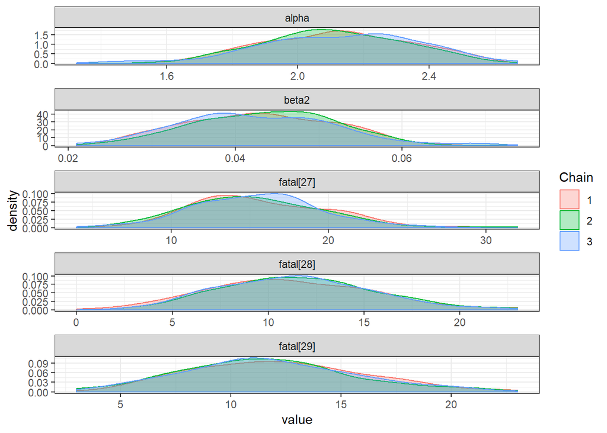

```r
result3 = ggs(a3.res)
ggs_density(result3)
```

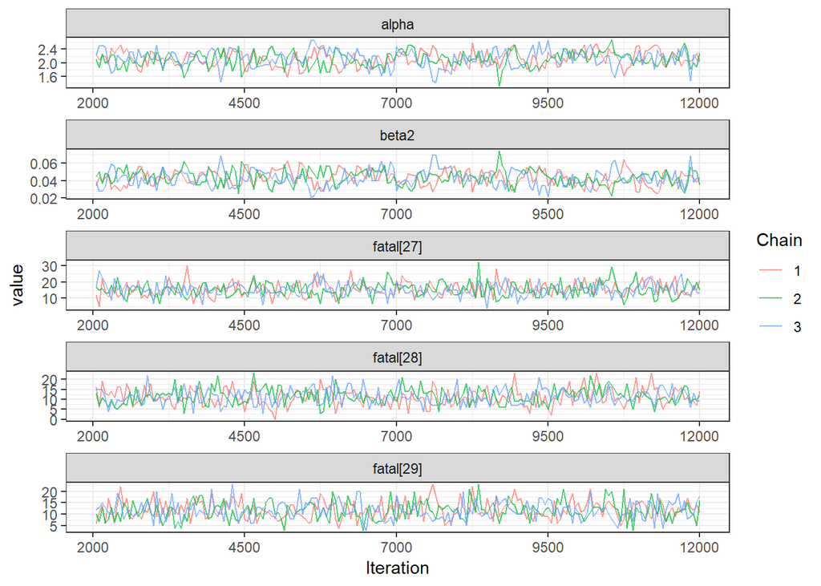

```r
ggs_traceplot(result3)
```

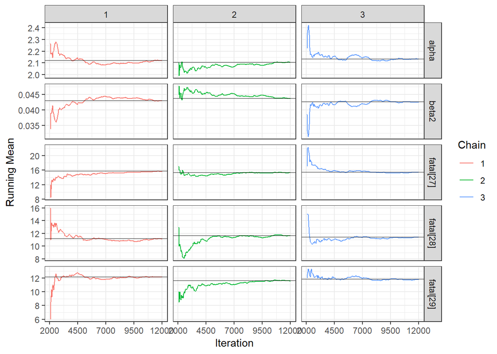

```r
ggs_running(result3)
```

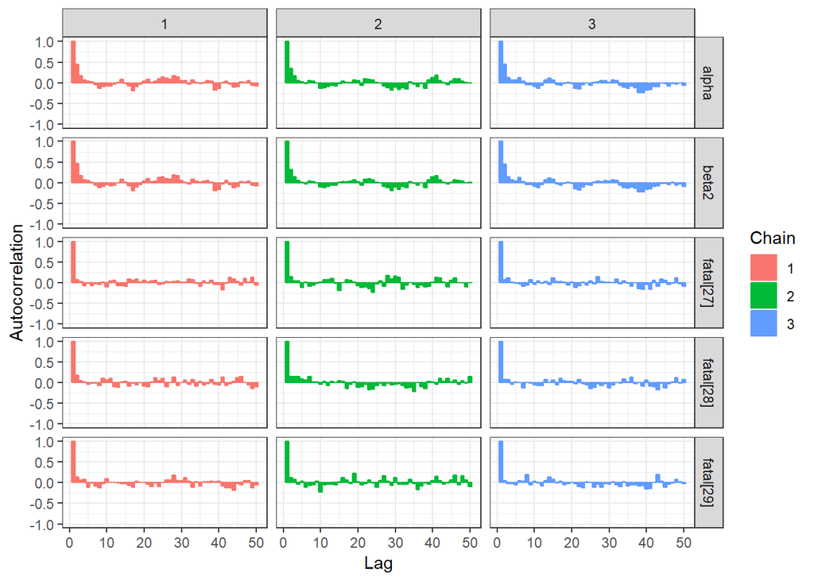

```r
ggs_autocorrelation(result3)
```

# Model 4 test

```r
library(rjags)
 cat( "model
 {
 for( i in 1:I )
 {
 fatal[i] ~ dnorm( mu[i],1/mu[i] )
 mu[i] <- alpha + beta2 * miles[i]
 }
 alpha ~ dnorm(0,0.0001)
 beta2 ~ dnorm(0,0.0001)
 }",
 file="a4.jag" )

 a4.ini= list(
    list(alpha = 0.01, beta2=3),
    list(alpha = 0.2, beta2=1),
    list(alpha = 0.7, beta2=2))
 a4.dat <- list( rate = c(airline$rate,0.7080,0.3),fatal=c(airline$fatal,NA,NA), miles=c(airline$miles,19.775,23.300), I=28 )
 a4.par <- c("alpha","beta2","fatal[27]","fatal[28]")

 # Model compilation and burn-in
 a4.mod <- jags.model(file = "a4.jag",data = a4.dat,inits = a4.ini,n.chains = 3,n.adapt = 1000 )
 # Sampling from the posterior
 update(a4.mod,1000)
 a4.res <- coda.samples( a4.mod,var = a4.par,n.iter = 3000,thin = 10 )
 summary( a4.res )
```

```
##
## Iterations = 2010:5000
## Thinning interval = 10
## Number of chains = 3
## Sample size per chain = 300
##
## 1. Empirical mean and standard deviation for each variable,
##    plus standard error of the mean:
##
##              Mean     SD Naive SE Time-series SE
## alpha     27.6762 2.5482 0.084939        0.12437
## beta2     -0.2996 0.2194 0.007314        0.01104
## fatal[27] 21.7037 5.3238 0.177460        0.18415
## fatal[28] 20.6625 5.4477 0.181592        0.19508
##
## 2. Quantiles for each variable:
##
##              2.5%     25%     50%     75%   97.5%
## alpha     22.8216 25.9899 27.5619 29.3358 32.7639
## beta2     -0.7306 -0.4528 -0.2936 -0.1557  0.1247
## fatal[27] 11.4284 18.1217 21.6176 25.3350 32.4952
## fatal[28] 10.6804 16.7065 20.5949 24.1685 31.6884
```

```r
 #predictions
```

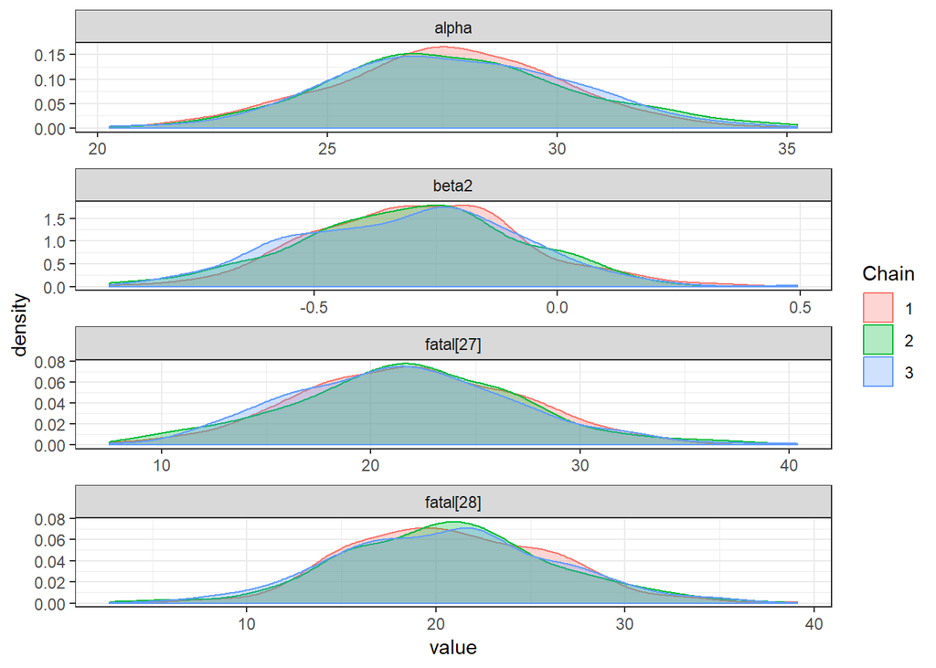

```r
result4 = ggs(a4.res)
ggs_density(result4)
```

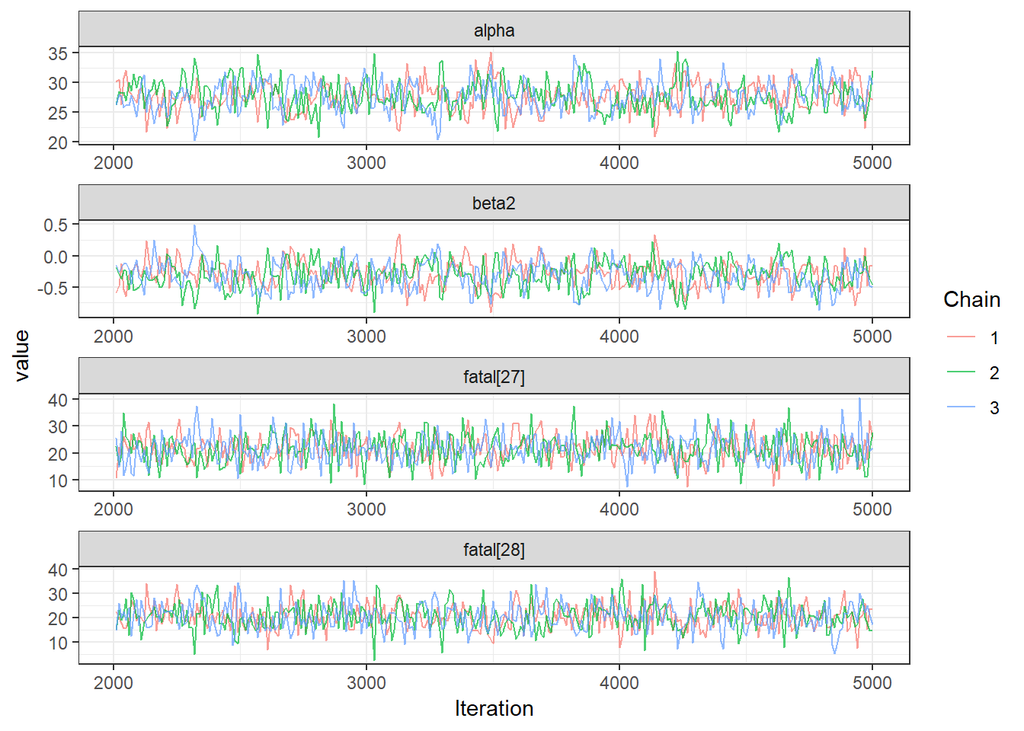

```r
ggs_traceplot(result4)
```

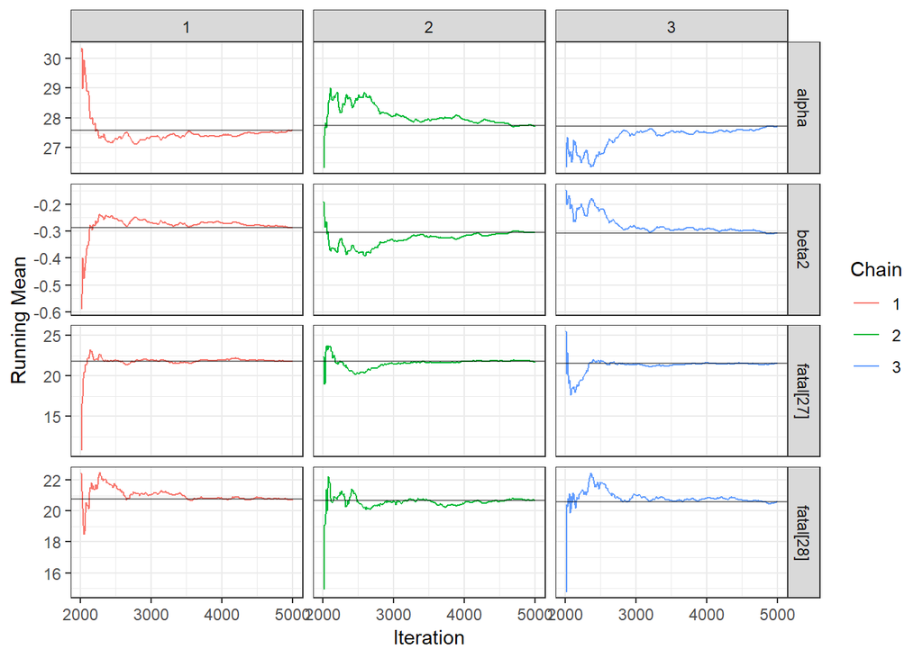

```r
ggs_running(result4)
```

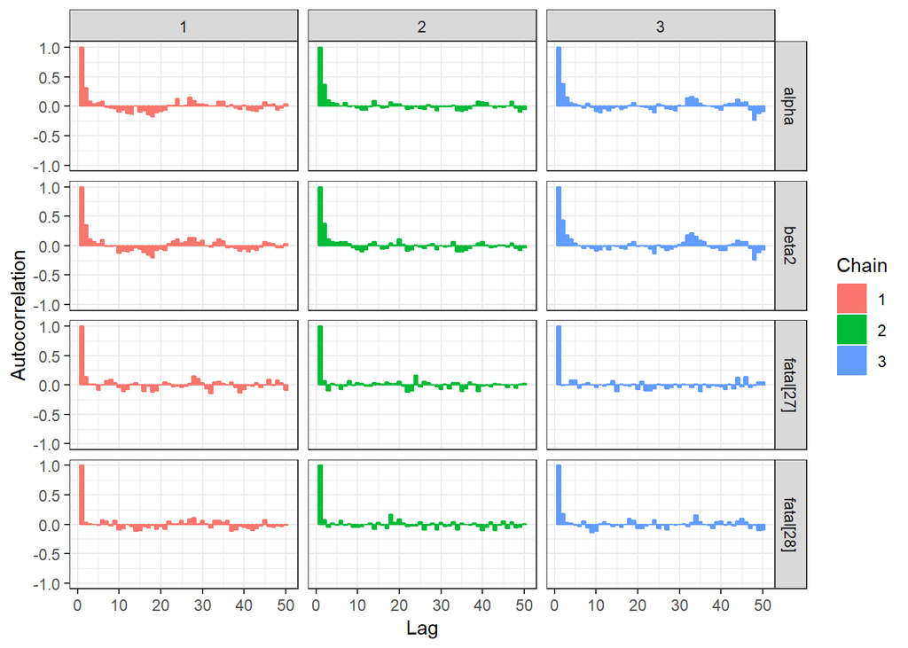

```r
ggs_autocorrelation(result4)
```

```r
 a3.m <- as.matrix(a33.res)
log.enum.2002 <- a3.m[,"alpha"] + a3.m[,"beta"]*19.775
#print(exp(log.enum.2002))
summary( exp(log.enum.2002 ))
```

```
##    Min. 1st Qu.  Median    Mean 3rd Qu.    Max.
##   4.143   7.049   8.322   8.503   9.730  15.598
```

```r
v =exp(log.enum.2002 )
#plot(density(v))
(e2002.qnt <- quantile( v, probs=c(50,2.5,97.5)/100))
```

```
##       50%      2.5%     97.5%
##  8.322105  5.238252 12.760700
```

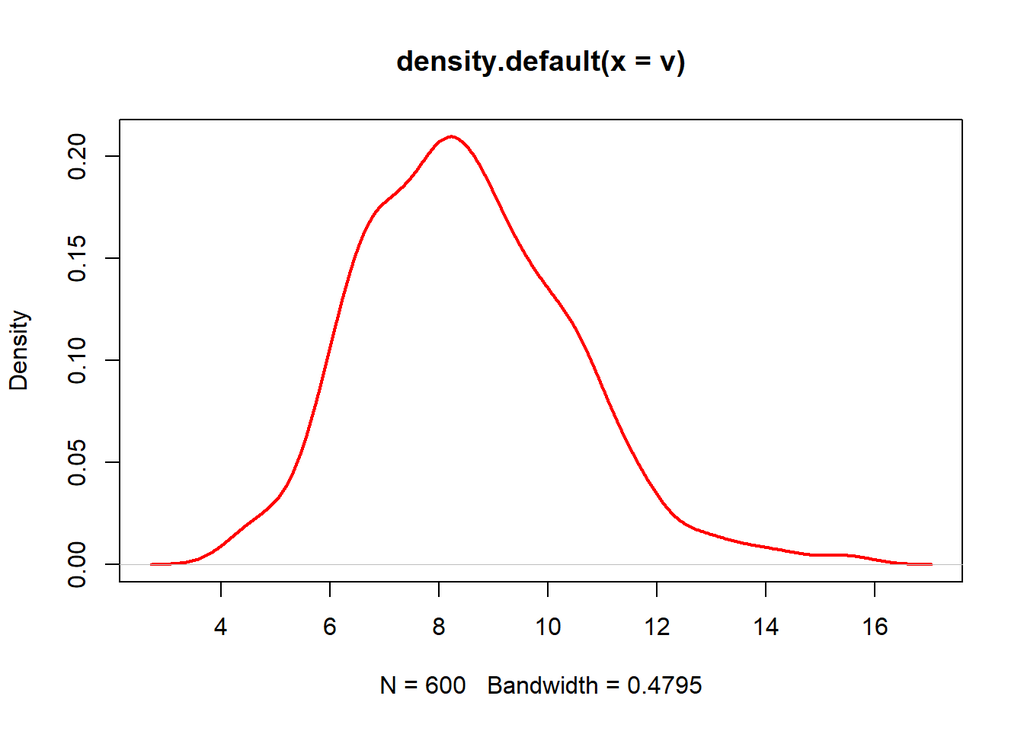

```r
plot( density(v), type="l", lwd=2, col= "red" )
abline( c=e2002.qnt)
```

## Prediction

We want to predict the expected number of airlines fatalities in 2002 (assuming that the amount of miles flown is $ 2010^{12}$ ), so we need the posterior of $exp( \alpha + \beta \times (2002-1985))\times 20$

```r
a2.m <- as.matrix(a2.res)
enum.2002 <- exp(a2.m[,"alpha"] + a2.m[,"beta"]*17)*20
summary( enum.2002 )
```

```
##    Min. 1st Qu.  Median    Mean 3rd Qu.    Max.
##   15.20   18.99   20.13   20.17   21.30   27.13
```

```r
(e2002.qnt <- quantile( enum.2002, probs=c(50,2.5,97.5)/100))
```

```
##      50%     2.5%    97.5%
## 20.12760 16.87417 23.73114
```

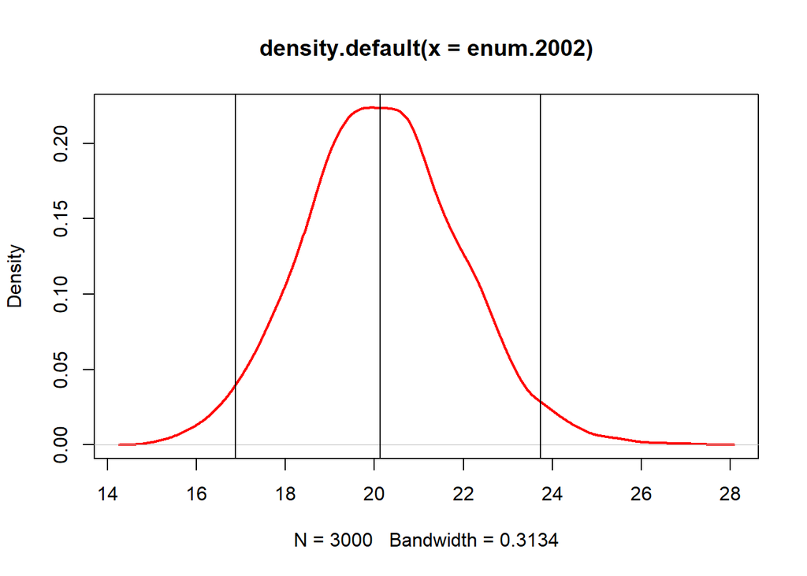

```r
plot( density(enum.2002), type="l", lwd=2, col= "red" )
abline( v=e2002.qnt)
```

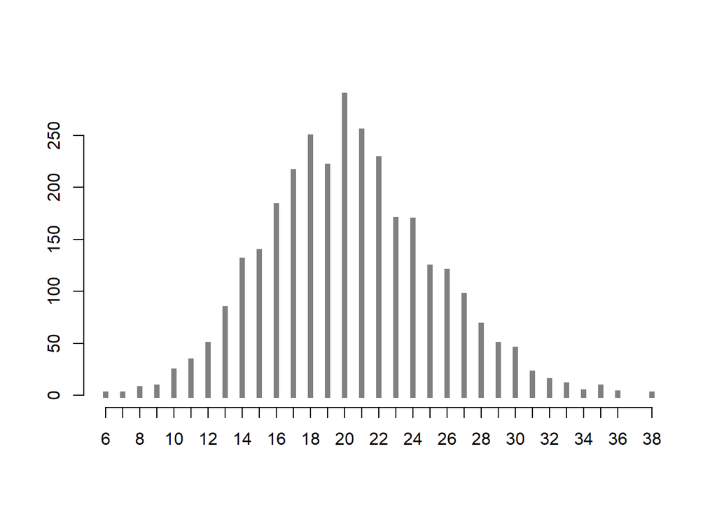

```r
plot( table(a2.m[,"fatal[27]"]), type="h", lwd=5, lend=2, col=gray(0.5), bty="n", ylab="" )
```

```
  Year      Fatal accidents   Passenger miles    Accident rate


  2002      14                19.775             0.7080
  2003      7                 23.300             0.3004
  2004      9                 20.300             0.4433
```

## Model comparison throughout DIC index

A good way to select the model that fits best our data, is using the DIC measure. The DIC (deviance information criterion) is a Bayesian criterion for model comparison, defined as:
$$DIC = D(\bar{\theta}) + 2_{p_D}$$
Where: $D(\theta) = -2logL(\theta)$, $p_D = \bar D - D(\bar \theta)$, is the effective number of paramenters of the model, the larger $p_D$ the easier the model fits on the data. $\bar D = E[D(\theta)]$, its the mean deviance. is a measure of how well the model fits the data, the larger the worse the fit. $D(\bar \theta) = D[E(\theta)]$

the basic idea is that the models with smaller DIC should be preferred. Models are penalized both by the value of $\bar D$, which favors a good fit, but also by the effective number of parameters $p_D$. Since $\bar D$ will decrease as the number of parameters in a model increases, the $p_{D}$ term compensates for this effect by favoring models with a smaller number of parameters.

```r
#Model Comparison
DICmod1 = dic.samples(a1.mod, n.iter=10000, thin=10, type="pD")
DICmod2 = dic.samples(a2.mod, n.iter=10000, thin =10, type="pD")
print('model 1 DIC')
```

```
## [1] "model 1 DIC"
```

```r
DICmod1
```

```
## Mean deviance:  156.2
## penalty 1.016
## Penalized deviance: 157.3
```

```r
print('model 2 DIC')
```

```
## [1] "model 2 DIC"
```

```r
DICmod2
```

```
## Mean deviance:  155
## penalty 1.978
## Penalized deviance: 157
```